# Analyzing Peptide Data with the pmartRqc Package

### Summarize Data

The pmartRqc package contains two methods for data summarization and exploration that can be used as part of the quality control process: sequential projection pursuit principal components analysis (sppPCA) for dimension reduction and a correlation heat map.

#### Sequential Projection Pursuit Principal Components Analysis

sppPCA is a PCA algorithm that can be used in the presence of missing data. The principal components are calculated using projection pursuit estimation, which implements an expectation-maximization (EM) algorithm when data is missing. We use the `dim_reduction()` function in pmartRqc, specifying the dataset and the number of principal components to return (should we make this default to 2?). The `summary()` and `plot()` functions operate on the results of the `dim_reduction()` function.

Note that `dim_reduction()` requires that the `group_designation()` function has been run.

```r
pca_results <- dim_reduction(mypepData, k = 2)

summary(pca_results)
```

```
## Summary of 'dimRes' Object
##
##     R_squared
## PC1     0.762
## PC2     0.175
```

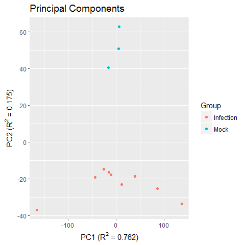

```r
plot(pca_results)
```

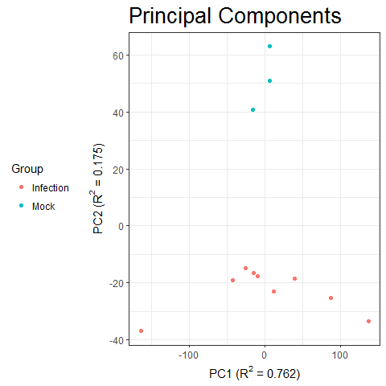

```r
plot(pca_results, title_size = 20, bw_theme=TRUE, legend_position="left")
```

#### Correlation Heatmap

```r
correlation_results <- cor_result(mypepData)

summary(correlation_results)
```

```
## Summary of Correlation Matrix (Upper Triangle)
##
##    Min. 1st Qu.  Median    Mean 3rd Qu.    Max.
##  0.7804  0.8688  0.9143  0.9032  0.9496  0.9722
```

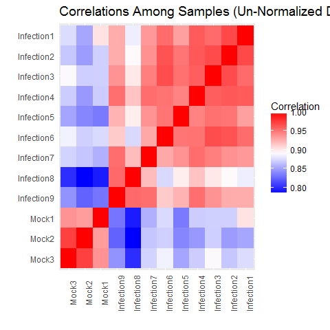

```r
plot(correlation_results)
```

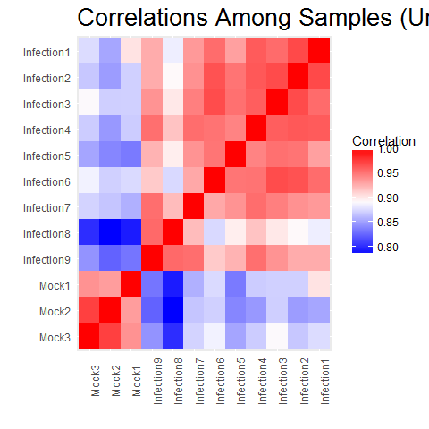

```r
plot(correlation_results, title_size = 20)
```

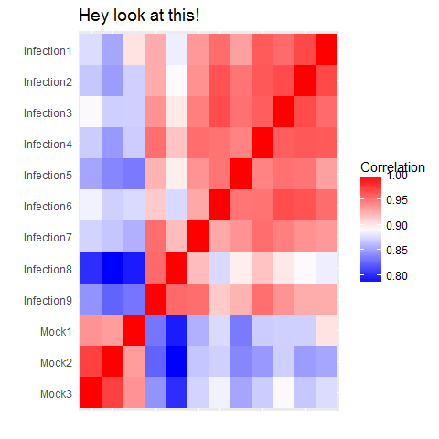

```r
plot(correlation_results, x_lab=FALSE, title_plot="Hey look at this!")
```

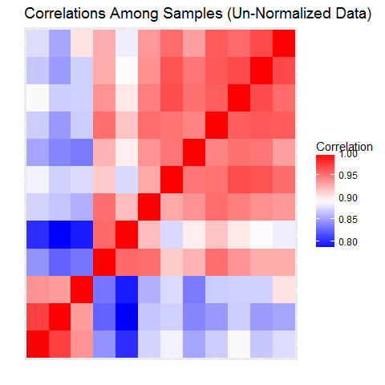

```r
plot(correlation_results, x_lab=FALSE, y_lab=FALSE)
```

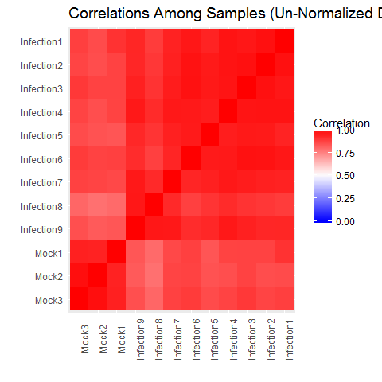

```r
plot(correlation_results, colorbar_lim=c(0,1))
```

## References

Ahmed, SE. 1995. “A Pooling Methodology for Coefficient of Variation.” *Sankhyā: The Indian Journal of Statistics, Series B*. JSTOR, 57–75.